# Project: Investigate a Dataset (IMDB-Movie Dataset)

## By Ayodele F. Ayodeji

## Investigation Overview

> In this investigation, I wanted to look at most popular genre from year to year, follow by director with highest movie popularity and year of production and finally, movie production company that has the highest revenue and the corresponding year.

## Dataset Overview

> This dataset includes information about Internet Movie Database (IMDB) movie. The data consists of information regarding 10,000 movies collected from The Movie Database (IMDb) including user ratings and revenue.

## Distribution of Popularity

> Popularity variable skewed to the rigth and lower percentage of popularity values (0 to about 3.4) are more in the dataframe

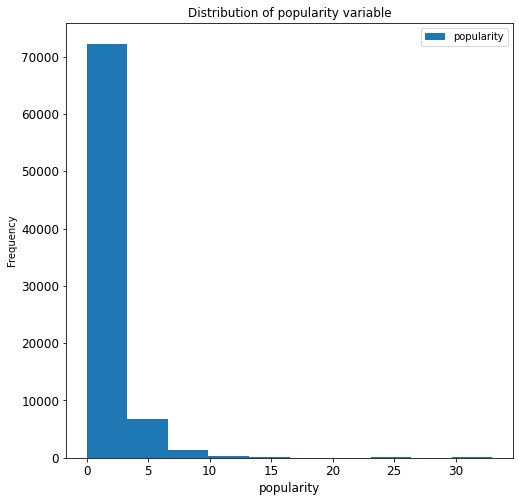

> The histogram distribution plot of released_year shows is skewed to the left and most of the imdb movie in this dataset was realeased in year 2002 to 2015.

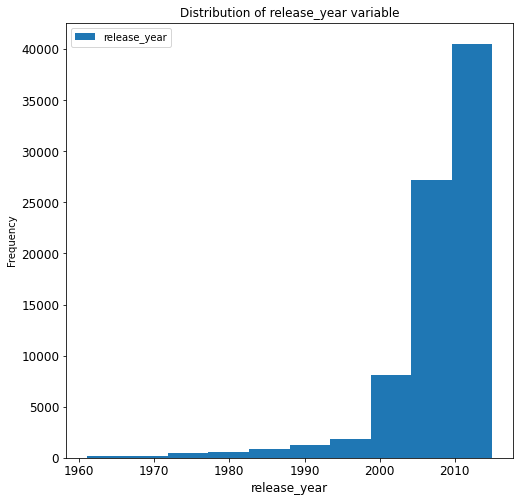

## Correlation Between Genre and Popularity

> This shows that popularity has weak correlation with genres variable

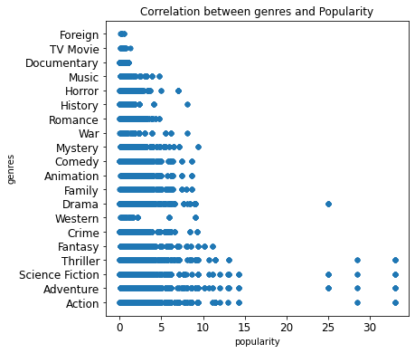

## Most popular Genre from year to year

> We have total of 4 genres with the highest popularity from year to year with same popularity value of 32.985763. The 4 genres include Action, Adventure, Science fiction and Thriller

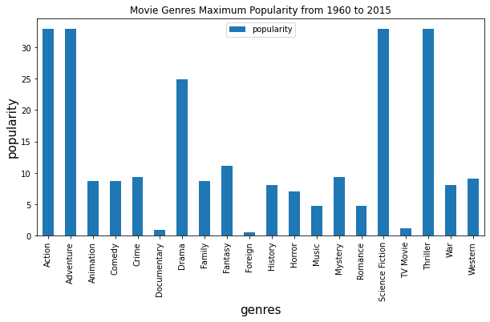

## Director that has the highest movie popularity and the corresponding year

> The director who has the highest popular movie was Colin Trevorrow with popularity rating of 32.985763. The movie was released in the year 2015, with original title 'Jurassic World'

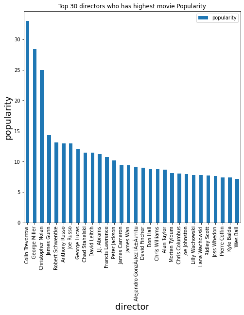

## Movie, production company that has the highest revenue and the corresponding year

> Avatar has the highest revenue of 2,781,505,847 in the year 2009. The movie(Avatar) was produced by 4 movie production companies namely;
- Ingenious Film Partners
- Dune Entertainment
- Twentieth Century Fox Film Corporation
- Lightstorm Entertainment

> The 4 companies all made the production in the year 2009 with same revenue of 2,781,505,847

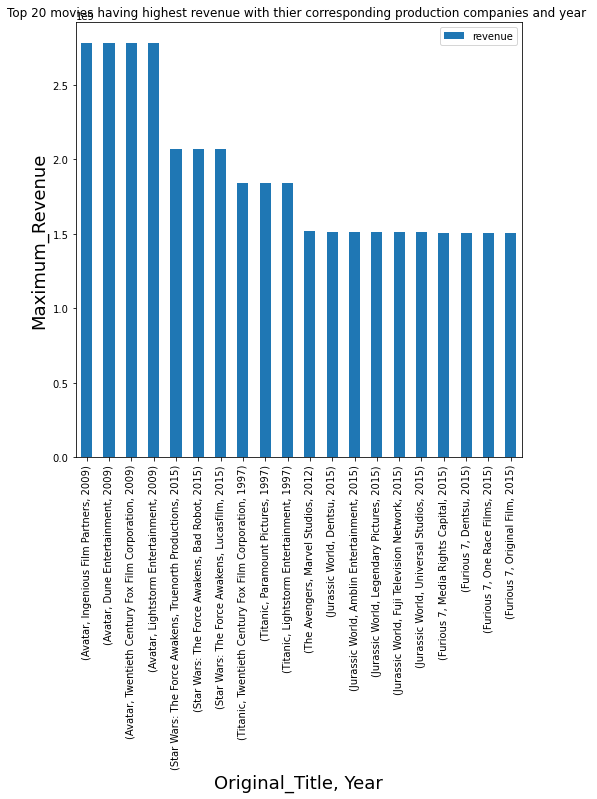